# R Aula 04

# Regressão linear simples

Para escolher um arquivo pelo prompt usar o file.choose

```r
#dados <- read.csv(file.choose(), sep = ';', dec = ',', header = T)
dados <- read.csv("vendas.csv", sep = ';', dec = ',', header = T)
dados
```

| preco | vendas |
| --- | --- |
| 120 | 10 |
| 200 | 20 |
| 600 | 40 |
| 410 | 30 |
| 350 | 25 |
| 250 | 22 |
| 800 | 25 |
| 500 | 35 |
| 630 | 41 |
| 780 | 50 |

[output cut: 1 more lines]

```r
head(dados)
```

|  | preco | vendas |
| --- | --- | --- |
| 1 | 120 | 10 |
| 2 | 200 | 20 |
| 3 | 600 | 40 |
| 4 | 410 | 30 |
| 5 | 350 | 25 |
| 6 | 250 | 22 |

```r
cor(dados)
```

```
##            preco    vendas
## preco  1.0000000 0.8057147
## vendas 0.8057147 1.0000000
```

lm -> linear model

```r
modelo <-  lm(vendas ~ preco, data = dados)
modelo
```

```
##
## Call:
## lm(formula = vendas ~ preco, data = dados)
##
## Coefficients:
## (Intercept)        preco
##    10.71139      0.04045
```

```r
modelo$coefficients
```

```
## (Intercept)       preco
##  10.7113890   0.0404484
```

```r
previsao <- modelo$coefficients[1] + modelo$coefficients[2] * 340
previsao
```

```
## (Intercept)
##    24.46384
```

```r
previsao <- predict(modelo, data.frame(preco = c(230,450,710,190,340)))
round(previsao)
```

```
##  1  2  3  4  5
## 20 29 39 18 24
```

# Regressão logística

USa o csv de eleicao

```r
eleicao <- read.csv2("Eleicao.csv", sep = ';')
eleicao
```

| CANDIDATO | SITUACAO | DESPESAS |
| --- | --- | --- |
| George Turner | 0 | 10 |
| Victor Johnson | 0 | 100 |
| Jerry Perry | 1 | 1600 |
| Shirley Cook | 1 | 1500 |
| Carolyn Bailey | 1 | 3300 |
| Susan Sanders | 0 | 200 |
| Anthony Harris | 1 | 1800 |
| Philip Richardson | 1 | 1700 |
| Eugene Phillips | 0 | 300 |
| Mildred Morris | 1 | 1800 |

[output cut: 37 more lines]

Como só tem duas variáveis o plot é de dispersão

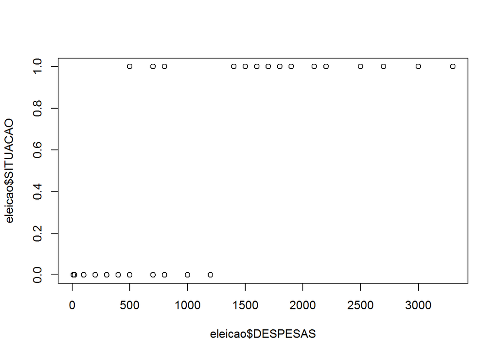

```r
plot(eleicao$DESPESAS, eleicao$SITUACAO)
```

```r
summary(eleicao)
```

```
##              CANDIDATO     SITUACAO         DESPESAS
##   Gary Peterson   : 1   Min.   :0.0000   Min.   :  10
##   Pamela Bryant   : 1   1st Qu.:0.0000   1st Qu.: 300
##  Andrea Washington: 1   Median :1.0000   Median : 800
##  Annie Brooks     : 1   Mean   :0.5106   Mean   :1086
##  Anthony Harris   : 1   3rd Qu.:1.0000   3rd Qu.:1700
##  Barbara White    : 1   Max.   :1.0000   Max.   :3300
##  (Other)          :41
```

```r
cor(eleicao$DESPESAS, eleicao$SITUACAO)
```

```
## [1] 0.8121872
```

### Modelo de regressão logística

```r
modelo <- glm(SITUACAO ~ DESPESAS, data = eleicao, family = 'binomial')
modelo
```

```
##
## Call:  glm(formula = SITUACAO ~ DESPESAS, family = "binomial", data = eleicao)
##
## Coefficients:
## (Intercept)     DESPESAS
##   -4.602880     0.004984
##
## Degrees of Freedom: 46 Total (i.e. Null);  45 Residual
## Null Deviance:       65.13
## Residual Deviance: 18.54     AIC: 22.54
```

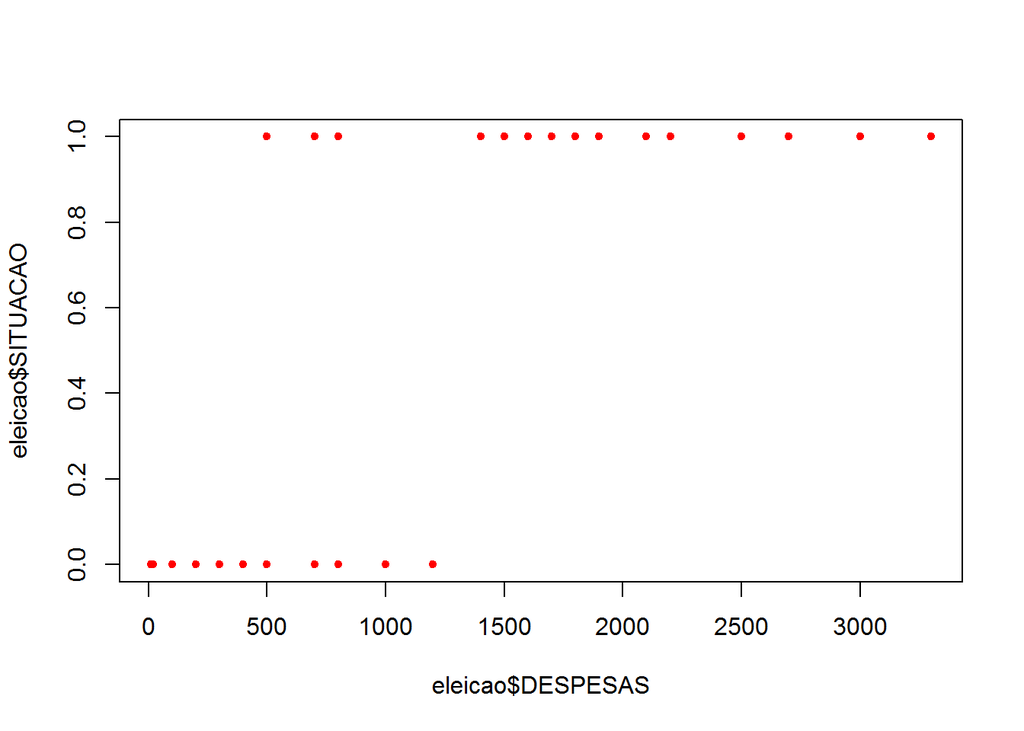

```r
plot(eleicao$DESPESAS, eleicao$SITUACAO, col = 'red', pch = 20)
```

```r
#pch é o código do ícone
```

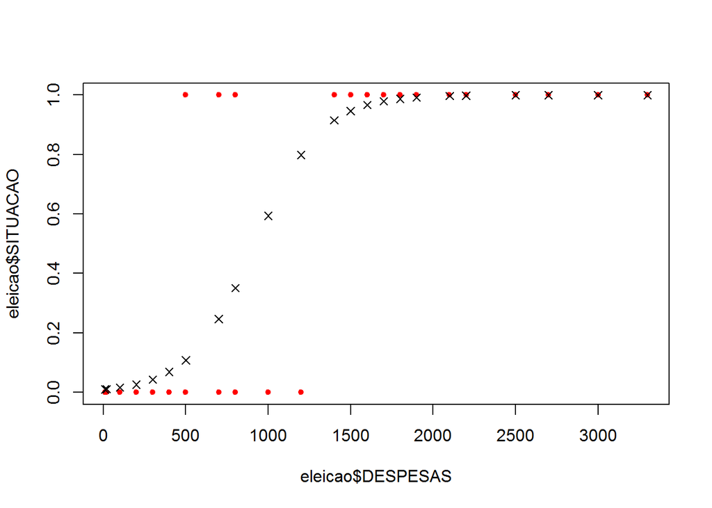

```r
plot(eleicao$DESPESAS, eleicao$SITUACAO, col = 'red', pch = 20)
points(eleicao$DESPESAS, modelo$fitted.values, pch = 4)
```

### Treinamento dos dados

```r
peleicao <- read.csv('NovosCandidatos.csv', sep = ';', header = T)
peleicao
```

| CANDIDATO | DESPESAS |
| --- | --- |
| A | 0 |
| B | 10 |
| C | 200 |
| D | 500 |
| E | 900 |
| F | 1500 |
| G | 3000 |

```r
peleicao$RESULT = predict(modelo, newdata = peleicao, type = 'response')

peleicao
```

| CANDIDATO | DESPESAS | RESULT |
| --- | --- | --- |
| A | 0 | 0.009923466 |
| B | 10 | 0.010425261 |
| C | 200 | 0.026438255 |
| D | 500 | 0.108027149 |
| E | 900 | 0.470635921 |
| F | 1500 | 0.946475247 |
| G | 3000 | 0.999967947 |

O result retorna a probabilidade de ser eleito entre 0 e 1

```r
peleicao$SITUACAO = (peleicao$RESULT * 100 > 85)

peleicao
```

| CANDIDATO | DESPESAS | RESULT | SITUACAO |
| --- | --- | --- | --- |
| A | 0 | 0.009923466 | FALSE |
| B | 10 | 0.010425261 | FALSE |
| C | 200 | 0.026438255 | FALSE |
| D | 500 | 0.108027149 | FALSE |
| E | 900 | 0.470635921 | FALSE |
| F | 1500 | 0.946475247 | TRUE |
| G | 3000 | 0.999967947 | TRUE |

```r
peleicao$SITUACAO = ifelse(peleicao$SITUACAO == T, 1, 0)
peleicao
```

| CANDIDATO | DESPESAS | RESULT | SITUACAO |
| --- | --- | --- | --- |
| A | 0 | 0.009923466 | 0 |
| B | 10 | 0.010425261 | 0 |
| C | 200 | 0.026438255 | 0 |
| D | 500 | 0.108027149 | 0 |
| E | 900 | 0.470635921 | 0 |
| F | 1500 | 0.946475247 | 1 |
| G | 3000 | 0.999967947 | 1 |

## Distribuição de poisson

Distribuição de um intervalo de tempo Num lugar com a media de 2 acidentes por dia qual a chance de ocorrer 3 acidentes?

x = 3 media_acidentes = 2

```r
x = 3
media_acidentes = 2
dpois(x, lambda = media_acidentes)
```

```
## [1] 0.180447
```

Mas e se for para descobrir a probabilidade de ser <= 3

```r
ppois(x, lambda = media_acidentes)
```

```
## [1] 0.8571235
```

Mas e se for > 3

```r
ppois(x, lambda = media_acidentes, lower.tail = F)
```

```
## [1] 0.1428765
```

# Series temporais (Forecast)

Estuda o comportamento de uma varável continua ao longo do tempo

Areas:

- Economia
- Previsão do tempo
- Previsão Financeira

Estacionarias - Flutuam em torno de uma mesma média Não estacionarias - Contêm mudanças acentuadas

Estocásticas - Formula + Fator aleatória, não pode ser explicado Determinísticas - Explicadas através de uma formula

Componentes:

- Tendência - conte funcao
- Sazionalidade - contem funcao
- Aleatoriedade - não possui explicação

```r
AirPassengers
```

```
##      Jan Feb Mar Apr May Jun Jul Aug Sep Oct Nov Dec
## 1949 112 118 132 129 121 135 148 148 136 119 104 118
## 1950 115 126 141 135 125 149 170 170 158 133 114 140
## 1951 145 150 178 163 172 178 199 199 184 162 146 166
## 1952 171 180 193 181 183 218 230 242 209 191 172 194
## 1953 196 196 236 235 229 243 264 272 237 211 180 201
## 1954 204 188 235 227 234 264 302 293 259 229 203 229
## 1955 242 233 267 269 270 315 364 347 312 274 237 278
## 1956 284 277 317 313 318 374 413 405 355 306 271 306
## 1957 315 301 356 348 355 422 465 467 404 347 305 336
## 1958 340 318 362 348 363 435 491 505 404 359 310 337
## 1959 360 342 406 396 420 472 548 559 463 407 362 405
## 1960 417 391 419 461 472 535 622 606 508 461 390 432
```

A primeira coluna sem nome repsenta o índice, e numa série temporal normalmente é o tempo, nesse caso anos

Inicio e fim

```r
start(AirPassengers)
```

```
## [1] 1949    1
```

```r
end(AirPassengers)
```

```
## [1] 1960   12
```

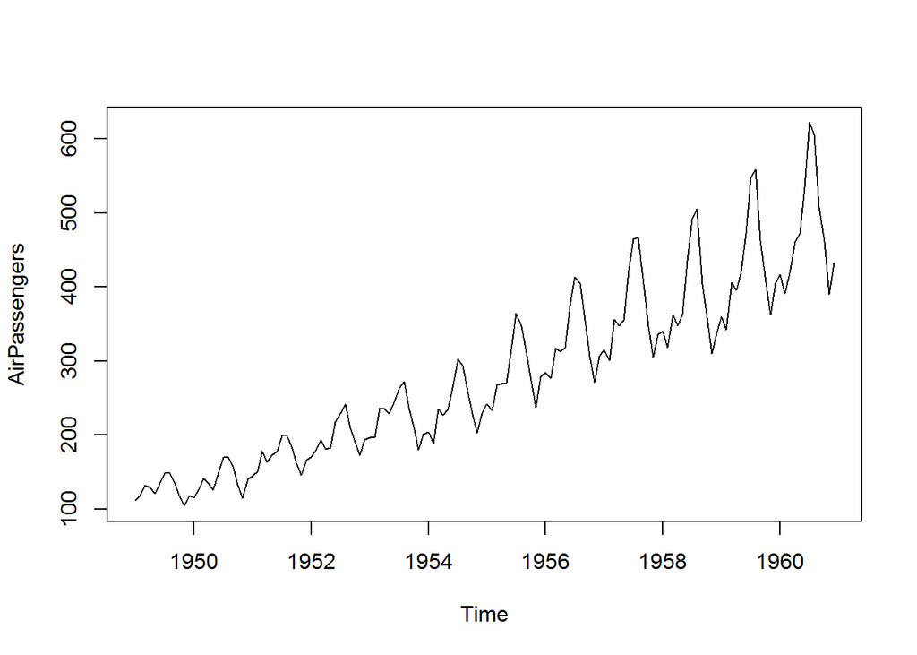

```r
plot(AirPassengers)
```

Substrato de uma serie temporal

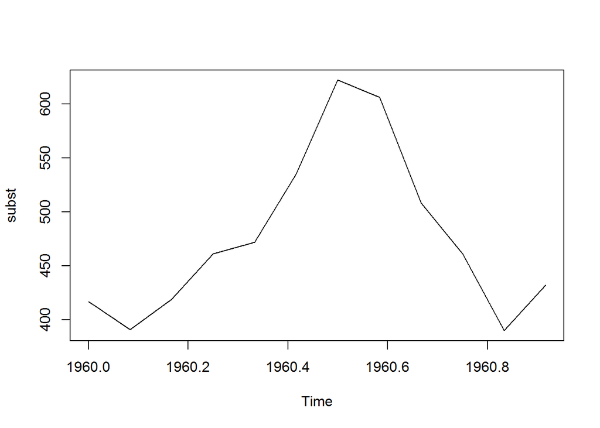

```r
subst <-  window(AirPassengers, start=c(1960,1), end=c(1960,12))
plot(subst)
```

### Partes

Decomposição de série temporal

```r
dec <- decompose(AirPassengers)

dec
```

```
## $x
##      Jan Feb Mar Apr May Jun Jul Aug Sep Oct Nov Dec
## 1949 112 118 132 129 121 135 148 148 136 119 104 118
## 1950 115 126 141 135 125 149 170 170 158 133 114 140
## 1951 145 150 178 163 172 178 199 199 184 162 146 166
## 1952 171 180 193 181 183 218 230 242 209 191 172 194
## 1953 196 196 236 235 229 243 264 272 237 211 180 201
## 1954 204 188 235 227 234 264 302 293 259 229 203 229
## 1955 242 233 267 269 270 315 364 347 312 274 237 278
## 1956 284 277 317 313 318 374 413 405 355 306 271 306
## 1957 315 301 356 348 355 422 465 467 404 347 305 336
## 1958 340 318 362 348 363 435 491 505 404 359 310 337
## 1959 360 342 406 396 420 472 548 559 463 407 362 405
## 1960 417 391 419 461 472 535 622 606 508 461 390 432
##
```

[output cut: 106 more lines]

Sasionalidade

```r
dec$seasonal
```

```
##             Jan        Feb        Mar        Apr        May        Jun
## 1949 -24.748737 -36.188131  -2.241162  -8.036616  -4.506313  35.402778
## 1950 -24.748737 -36.188131  -2.241162  -8.036616  -4.506313  35.402778
## 1951 -24.748737 -36.188131  -2.241162  -8.036616  -4.506313  35.402778
## 1952 -24.748737 -36.188131  -2.241162  -8.036616  -4.506313  35.402778
## 1953 -24.748737 -36.188131  -2.241162  -8.036616  -4.506313  35.402778
## 1954 -24.748737 -36.188131  -2.241162  -8.036616  -4.506313  35.402778
## 1955 -24.748737 -36.188131  -2.241162  -8.036616  -4.506313  35.402778
## 1956 -24.748737 -36.188131  -2.241162  -8.036616  -4.506313  35.402778
## 1957 -24.748737 -36.188131  -2.241162  -8.036616  -4.506313  35.402778
## 1958 -24.748737 -36.188131  -2.241162  -8.036616  -4.506313  35.402778
## 1959 -24.748737 -36.188131  -2.241162  -8.036616  -4.506313  35.402778
## 1960 -24.748737 -36.188131  -2.241162  -8.036616  -4.506313  35.402778
##             Jul        Aug        Sep        Oct        Nov        Dec
## 1949  63.830808  62.823232  16.520202 -20.642677 -53.593434 -28.619949
## 1950  63.830808  62.823232  16.520202 -20.642677 -53.593434 -28.619949
## 1951  63.830808  62.823232  16.520202 -20.642677 -53.593434 -28.619949
## 1952  63.830808  62.823232  16.520202 -20.642677 -53.593434 -28.619949
## 1953  63.830808  62.823232  16.520202 -20.642677 -53.593434 -28.619949
## 1954  63.830808  62.823232  16.520202 -20.642677 -53.593434 -28.619949
## 1955  63.830808  62.823232  16.520202 -20.642677 -53.593434 -28.619949
## 1956  63.830808  62.823232  16.520202 -20.642677 -53.593434 -28.619949
## 1957  63.830808  62.823232  16.520202 -20.642677 -53.593434 -28.619949
## 1958  63.830808  62.823232  16.520202 -20.642677 -53.593434 -28.619949
## 1959  63.830808  62.823232  16.520202 -20.642677 -53.593434 -28.619949
## 1960  63.830808  62.823232  16.520202 -20.642677 -53.593434 -28.619949
```

Tendência

```r
dec$trend
```

```
##           Jan      Feb      Mar      Apr      May      Jun      Jul
## 1949       NA       NA       NA       NA       NA       NA 126.7917
## 1950 131.2500 133.0833 134.9167 136.4167 137.4167 138.7500 140.9167
## 1951 157.1250 159.5417 161.8333 164.1250 166.6667 169.0833 171.2500
## 1952 183.1250 186.2083 189.0417 191.2917 193.5833 195.8333 198.0417
## 1953 215.8333 218.5000 220.9167 222.9167 224.0833 224.7083 225.3333
## 1954 228.0000 230.4583 232.2500 233.9167 235.6250 237.7500 240.5000
## 1955 261.8333 266.6667 271.1250 275.2083 278.5000 281.9583 285.7500
## 1956 309.9583 314.4167 318.6250 321.7500 324.5000 327.0833 329.5417
## 1957 348.2500 353.0000 357.6250 361.3750 364.5000 367.1667 369.4583
## 1958 375.2500 377.9167 379.5000 380.0000 380.7083 380.9583 381.8333
## 1959 402.5417 407.1667 411.8750 416.3333 420.5000 425.5000 430.7083
## 1960 456.3333 461.3750 465.2083 469.3333 472.7500 475.0417       NA
##           Aug      Sep      Oct      Nov      Dec
## 1949 127.2500 127.9583 128.5833 129.0000 129.7500
## 1950 143.1667 145.7083 148.4167 151.5417 154.7083
## 1951 173.5833 175.4583 176.8333 178.0417 180.1667
## 1952 199.7500 202.2083 206.2500 210.4167 213.3750
## 1953 225.3333 224.9583 224.5833 224.4583 225.5417
## 1954 243.9583 247.1667 250.2500 253.5000 257.1250
## 1955 289.3333 293.2500 297.1667 301.0000 305.4583
## 1956 331.8333 334.4583 337.5417 340.5417 344.0833
## 1957 371.2083 372.1667 372.4167 372.7500 373.6250
## 1958 383.6667 386.5000 390.3333 394.7083 398.6250
## 1959 435.1250 437.7083 440.9583 445.8333 450.6250
## 1960       NA       NA       NA       NA       NA
```

Aleatoriedade

```r
dec$random
```

```
##              Jan         Feb         Mar         Apr         May
## 1949          NA          NA          NA          NA          NA
## 1950   8.4987374  29.1047980   8.3244949   6.6199495  -7.9103535
## 1951  12.6237374  26.6464646  18.4078283   6.9116162   9.8396465
## 1952  12.6237374  29.9797980   6.1994949  -2.2550505  -6.0770202
## 1953   4.9154040  13.6881313  17.3244949  20.1199495   9.4229798
## 1954   0.7487374  -6.2702020   4.9911616   1.1199495   2.8813131
## 1955   4.9154040   2.5214646  -1.8838384   1.8282828  -3.9936869
## 1956  -1.2095960  -1.2285354   0.6161616  -0.7133838  -1.9936869
## 1957  -8.5012626 -15.8118687   0.6161616  -5.3383838  -4.9936869
## 1958 -10.5012626 -23.7285354 -15.2588384 -23.9633838 -13.2020202
## 1959 -17.7929293 -28.9785354  -3.6338384 -12.2967172   4.0063131
## 1960 -14.5845960 -34.1868687 -43.9671717  -0.2967172   3.7563131
##              Jun         Jul         Aug         Sep         Oct
## 1949          NA -42.6224747 -42.0732323  -8.4785354  11.0593434
```

[output cut: 24 more lines]

### Previsão

Para fazer a predição se usa a estrapolação, ou seja, a previsão está fora dos meus dados e de sua média.

Ele trabalha dentro de um intervalo de segurança

```r
mean(AirPassengers)
```

```
## [1] 280.2986
```

Média da janela do último ano

```r
mean(window(AirPassengers, start=c(1960,1), end=c(1960,12)))
```

```
## [1] 476.1667
```

Para trabalhar com médias moveis usa o pacote forecast

```r
library(forecast)
```

- ma - conjunto de dados
- order - quantidade de meses

```r
mediam <- ma(AirPassengers, order = 12)
mediam
```

```
##           Jan      Feb      Mar      Apr      May      Jun      Jul
## 1949       NA       NA       NA       NA       NA       NA 126.7917
## 1950 131.2500 133.0833 134.9167 136.4167 137.4167 138.7500 140.9167
## 1951 157.1250 159.5417 161.8333 164.1250 166.6667 169.0833 171.2500
## 1952 183.1250 186.2083 189.0417 191.2917 193.5833 195.8333 198.0417
## 1953 215.8333 218.5000 220.9167 222.9167 224.0833 224.7083 225.3333
## 1954 228.0000 230.4583 232.2500 233.9167 235.6250 237.7500 240.5000
## 1955 261.8333 266.6667 271.1250 275.2083 278.5000 281.9583 285.7500
## 1956 309.9583 314.4167 318.6250 321.7500 324.5000 327.0833 329.5417
## 1957 348.2500 353.0000 357.6250 361.3750 364.5000 367.1667 369.4583
## 1958 375.2500 377.9167 379.5000 380.0000 380.7083 380.9583 381.8333
## 1959 402.5417 407.1667 411.8750 416.3333 420.5000 425.5000 430.7083
## 1960 456.3333 461.3750 465.2083 469.3333 472.7500 475.0417       NA
##           Aug      Sep      Oct      Nov      Dec
## 1949 127.2500 127.9583 128.5833 129.0000 129.7500
## 1950 143.1667 145.7083 148.4167 151.5417 154.7083
## 1951 173.5833 175.4583 176.8333 178.0417 180.1667
## 1952 199.7500 202.2083 206.2500 210.4167 213.3750
## 1953 225.3333 224.9583 224.5833 224.4583 225.5417
## 1954 243.9583 247.1667 250.2500 253.5000 257.1250
## 1955 289.3333 293.2500 297.1667 301.0000 305.4583
## 1956 331.8333 334.4583 337.5417 340.5417 344.0833
## 1957 371.2083 372.1667 372.4167 372.7500 373.6250
## 1958 383.6667 386.5000 390.3333 394.7083 398.6250
## 1959 435.1250 437.7083 440.9583 445.8333 450.6250
## 1960       NA       NA       NA       NA       NA
```

### Previsão de forecast

```r
previsao <- forecast(mediam, h = 12)
previsao
```

```
##          Point Forecast    Lo 80    Hi 80    Lo 95    Hi 95
## Jul 1960       477.3335 475.9160 478.7509 475.1657 479.5013
## Aug 1960       479.6252 476.4529 482.7975 474.7735 484.4769
## Sep 1960       481.9169 476.6028 487.2310 473.7897 490.0441
## Oct 1960       484.2086 476.4207 491.9966 472.2980 496.1193
## Nov 1960       486.5003 475.9430 497.0576 470.3544 502.6463
## Dec 1960       488.7920 475.1962 502.3878 467.9990 509.5850
## Jan 1961       491.0837 474.2001 507.9674 465.2625 516.9050
## Feb 1961       493.3754 472.9704 513.7804 462.1687 524.5822
## Mar 1961       495.6672 471.5200 519.8143 458.7372 532.5971
## Apr 1961       497.9589 469.8594 526.0584 454.9844 540.9333
## May 1961       500.2506 467.9976 532.5035 450.9239 549.5772
## Jun 1961       502.5423 465.9425 539.1421 446.5677 558.5169
```

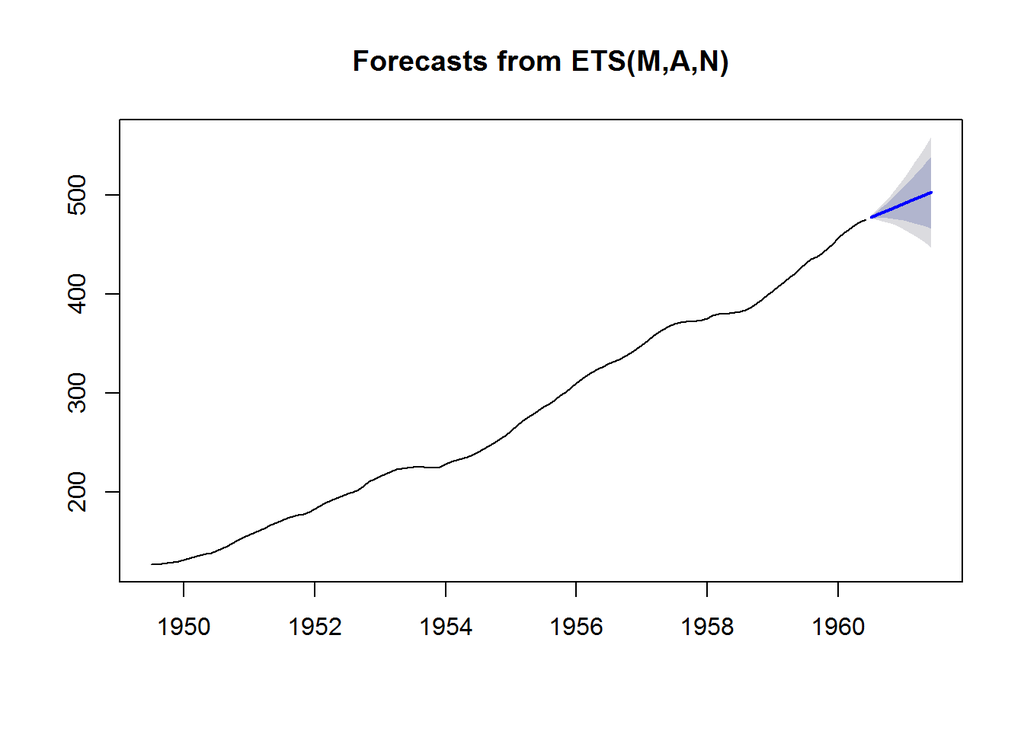

```r
plot(previsao)
```

## Função arima

```r
arima = auto.arima(AirPassengers)
arima
```

```
## Series: AirPassengers
## ARIMA(2,1,1)(0,1,0)[12]
##
## Coefficients:
##          ar1     ar2      ma1
##       0.5960  0.2143  -0.9819
## s.e.  0.0888  0.0880   0.0292
##
## sigma^2 estimated as 132.3:  log likelihood=-504.92
## AIC=1017.85   AICc=1018.17   BIC=1029.35
```

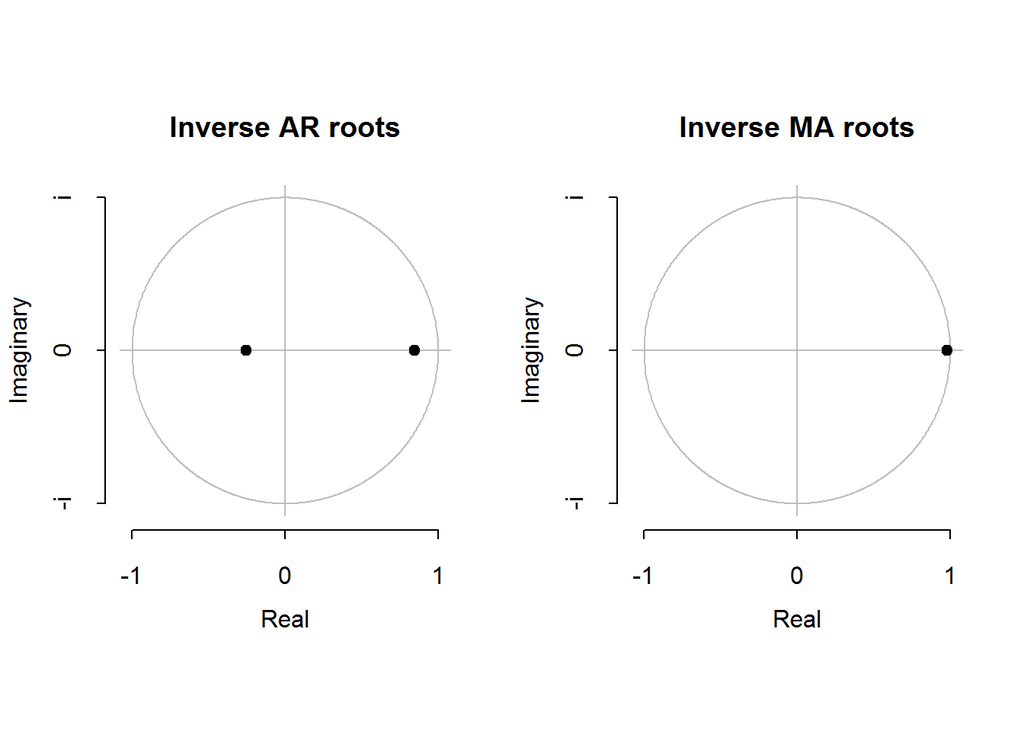

```r
plot(arima)
```

```r
previsao = forecast(arima, h = 24)
previsao
```

```
##          Point Forecast    Lo 80    Hi 80    Lo 95    Hi 95
## Jan 1961       445.6349 430.8903 460.3795 423.0851 468.1847
## Feb 1961       420.3950 403.0907 437.6993 393.9304 446.8596
## Mar 1961       449.1983 429.7726 468.6240 419.4892 478.9074
## Apr 1961       491.8399 471.0270 512.6529 460.0092 523.6707
## May 1961       503.3945 481.5559 525.2330 469.9953 536.7937
## Jun 1961       566.8624 544.2637 589.4612 532.3007 601.4242
## Jul 1961       654.2602 631.0820 677.4383 618.8122 689.7081
## Aug 1961       638.5975 614.9704 662.2246 602.4630 674.7320
## Sep 1961       540.8837 516.9028 564.8647 504.2081 577.5594
## Oct 1961       494.1266 469.8624 518.3909 457.0177 531.2356
## Nov 1961       423.3327 398.8381 447.8273 385.8715 460.7939
## Dec 1961       465.5076 440.8229 490.1923 427.7556 503.2596
## Jan 1962       479.2908 448.9986 509.5831 432.9629 525.6188
## Feb 1962       454.1768 421.7184 486.6353 404.5359 503.8178
## Mar 1962       483.0870 448.7343 517.4396 430.5491 535.6248
## Apr 1962       525.8193 490.1122 561.5263 471.2101 580.4284
## May 1962       537.4507 500.6863 574.2151 481.2244 593.6770
## Jun 1962       600.9839 563.3924 638.5754 543.4927 658.4752
## Jul 1962       688.4370 650.1834 726.6907 629.9331 746.9410
## Aug 1962       672.8213 634.0292 711.6134 613.4940 732.1487
## Sep 1962       575.1475 535.9102 614.3847 515.1393 635.1557
## Oct 1962       528.4242 488.8131 568.0352 467.8443 589.0040
## Nov 1962       457.6590 417.7293 497.5886 396.5918 518.7261
## Dec 1962       499.8582 459.6529 540.0634 438.3695 561.3468
```

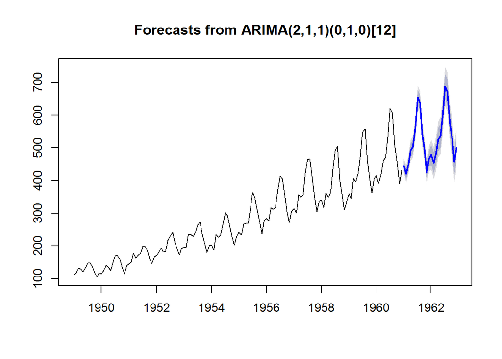

```r
plot(previsao)
```

# Machine Learning

É o desenvolvimento de técnicas computacionais usados para que o sistema adquira conhecimento de forma automática. Dados são usados como fonte de informação para uqe a máquina possa aprender.

Indução: É a forma de inferência lógica que permite obter conclusões a partir de um conjunto de exemplos

## CUidados na escolha dos exemplos

O aprendizado é continuo, ou seja, a maquina aprende mais conforme o tempo. O aprendizado é mensurável, podemos medir o tamanho do aprendizado. Durante o aprendizado a maquina cria um modelo depois de observado os dados historicos informados.